# R Notebook

### *MACS 205 : Interpolation et quadrature - Etude de cas*

#### 1. Introduction

On s’intéresse à la loi Beta de paramètres $\alpha > 0$, $\beta > 0$ de densité : $\phi_{\alpha,\beta}(x) = x^{\alpha - 1}(1-x)^{\beta - 1}/B_{\alpha, \beta}$

avec : $B_{\alpha, \beta} = \frac{\Gamma(\alpha)\Gamma(\beta)}{\Gamma(\alpha + \beta)}$

Pour la suite on prendra : $\alpha = 1.7$ et $\beta = 5.1$.

#### 2. Génération des données et fonctions préliminaires

*2.1.*

```r
  densite  = function(x) {
    return(dbeta(x, 1.7, 5.1))
  }
```

*2.2.* Par la loi forte des grands nombres, on obtient que $\widehat{\phi}^{N_{w}}_{1.7, 5.1} (x) \overset{p.s.}{\rightarrow} 2^{8}.\mathbb{P}(\omega \in [k(x)2^{-8}, (k(x)+1)2^{-8}[).$

*2.3.* On obtient :
$$\widehat{\phi}^{~\infty}_{1.7,5.1}(x)-{\phi}_{1.7,5.1}(x) = 2^8. \int^{(k(x)+1)2^{-8}}_{k(x)2^{-8}}{\phi}_{1.7,5.1}(u)-{\phi}_{1.7,5.1}(x)~du.$$

*2.4.* La fonction renvoie la fréquence correspondant à l’index de x, divisée par la largeur du pas pour obtenir une densité.

#### 3. Interpolation polynomiale

*3.1.* Interpolation à partir de l’expression exacte de $\phi_{1.7, 5.1}$

3.1.1

```r
dividif=function(x,y){
##  Newton's Divided differences
    n = length(x) - 1 ## degree of the Lagrange polynomial
    d  = y
    for (j in 2:(n+1) ) {
      d[j : (n+1) ] = (d[j : (n+1)] - d[(j-1):n])/(x[j:(n+1)] - x[1:(n+2-j)])
    }
    return(d)
}
hornerNewton = function(a,x,z){
    ## Horner's method: Evaluates  a polynom P at points z, given
    n = length(x);
    f  = a[n] * (z-x[n-1]) + a[n-1]
    for( i in 2:(n-1)){
        f = a[n-i] + f  * (z-x[n-i])
    }
    return(f)
}
interpolDividif=function(x,y,z){
    ## Efficient Lagrange interpolation using Horner's method with
    ## Newton basis for evaluation
    coeff = dividif(x,y)
    return (hornerNewton(coeff, x, z))
}
NTcheby = function(n, a, b){
  T = seq(0, n-1);
  for (k in (1:n)){
    T[k]= ((a+b)/2) + ((a-b)/2)*cos(((T[k]+(1/2))*pi)/n)}
  return (T)
}
  interpolLagrange =function(n, a, b, neval, nodes = 'equi', FUN){
      ## Generic Lagrange interpolation, with equidistant or Chebyshev nodes.
      ## @param n : the degree of the interpolating polynomial on each
      ## subinterval
      ## @param a : left end-point of the interval
      ## @param b : right end-point of the interval
      ## @param neval :number of evaluation points (a regular grid will be
      ## used on [a,b]
      ## @param nodes :string, either "equi" (default) for equidistant
      ## Lagrange interpolation (on each subinterval) or "cheby" for
      ## using Chebyshev nodes.
      ## @param FUN: the function to be interpolated
      ## @return : vector of size 'neval': the values of the Lagrange
      ## polynomial on an equi-distant grid.

      if (nodes == 'equi'){
          x =  seq(a,b,length.out=n)
              }
      else if (nodes == 'cheby'){
                  x = NTcheby(n,a,b)
                      }
      else{stop("the nodes must be either 'equi' or 'cheby'") }

      z = seq(a,b,length.out=neval)
      y = FUN(x)
      f = interpolDividif(x, y, z)

      return(f)
  }

   n_eval_test = 1000
  a_test = 2^(-8)
  b_test = 1 - a_test
  z = seq(0,1,length.out=n_eval_test)
  y = densite(z)
plot(z, sapply(z,densite), type="o",
     ylim=range(c(y,interpolLagrange(3, a_test, b_test, n_eval_test, 'equi', densite))),col = 'black')
grid()
```

```r
title(main = paste("Lagrange interpolation with 4 to 11 equidistant nodes"))
lines(z, interpolLagrange(3, a_test, b_test, n_eval_test, 'equi', densite), col = "green")
```

```r
lines(z, interpolLagrange(4, a_test, b_test, n_eval_test, 'equi', densite), col = "yellow")
lines(z, interpolLagrange(6, a_test, b_test, n_eval_test, 'equi', densite), col = "purple")
```

```r
lines(z, interpolLagrange(8, a_test, b_test, n_eval_test, 'equi', densite), col = "blue")
lines(z, interpolLagrange(10, a_test, b_test, n_eval_test, 'equi', densite), col = "red")
```

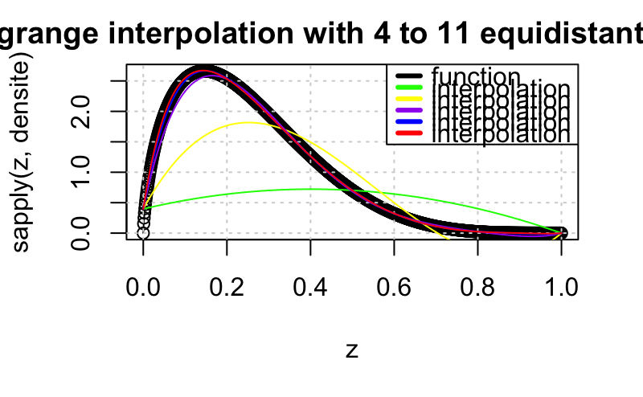

```r
legend('topright',
       legend=c('function','interpolation of degree 3',
        'interpolation of degree 4', 'interpolation of degree 6',
       'interpolation of degree 8', 'interpolation of degree 10'),
       col = c('black','green', 'yellow', 'purple', 'blue', 'red'), lwd=3)
```

```r
plot(z, sapply(z,densite), type="o",
     ylim=range(c(y,interpolLagrange(40, a_test, b_test, n_eval_test, 'equi', densite))),
     col = 'black')
grid()
```

```r
title(main = paste("Lagrange interpolation with 21 to 61 equidistant nodes"))
lines(z, interpolLagrange(20, a_test, b_test, n_eval_test, 'equi', densite), col = "green")
```

```r
lines(z, interpolLagrange(30, a_test, b_test, n_eval_test, 'equi', densite), col = "yellow")
lines(z, interpolLagrange(40, a_test, b_test, n_eval_test, 'equi', densite), col = "purple")
```

```r
lines(z, interpolLagrange(50, a_test, b_test, n_eval_test, 'equi', densite), col = "blue")
lines(z, interpolLagrange(58, a_test, b_test, n_eval_test, 'equi', densite), col = "red")
```

```r
lines(z, interpolLagrange(59, a_test, b_test, n_eval_test, 'equi', densite), col = "gray")
lines(z, interpolLagrange(60, a_test, b_test, n_eval_test, 'equi', densite), col = "blue")
```

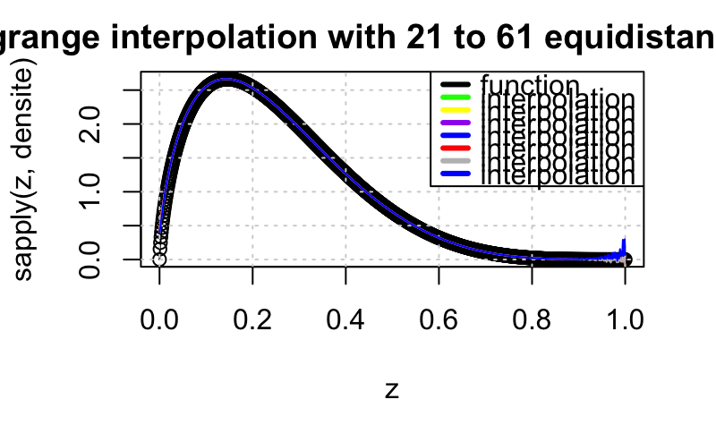

```r
legend('topright', legend=c('function','interpolation of degree 20',
                            'interpolation of degree 30', 'interpolation of degree 40',
                            'interpolation of degree 50', 'interpolation of degree 58',
                            'interpolation of degree 59', 'interpolation of degree 60'),
                            col = c('black','green', 'yellow', 'purple', 'blue', 'red', 'gray', 'blue'), lwd=3)
```

1. A partir d’un polynôme de degré 58, l’augmentation du degré ne constitue plus une bonne stratégie d’interpolation : il s’agit du phénomène de Runge. Alors qu’à un degré inférieur, l’interpolation est bonne.
2. :

```r
plot(z, sapply(z,densite), type="o",
     ylim=range(c(y,interpolLagrange(3, a_test, b_test, n_eval_test, 'equi', densite))),col = 'black')
grid()
```

```r
title(main = paste("Lagrange interpolation with 4 equidistant nodes"))
lines(z, interpolLagrange(3, a_test, b_test, n_eval_test, 'equi', densite), col = "red")
```